[figure not shown]

Clase 5: Distribuciones Binomial e Hipergeom´

etrica.

Aproximaci ´

on Binomial de la Hipergeom´

etrica

Profesora: Olga Alexandra Bustos Giraldo

Escuela de Estad´

ıstica

Universidad Nacional de Colombia, Sede Medell´

ın

oabustos@unal.edu.co

Estad´

ıstica I (Clase 5).

1

[figure not shown]

Combinatoria

Factorial

El factorial de un n´

umero entero positivo se deﬁne como el producto de todos

los n´

umeros naturales anteriores o iguales a ´

el, se escribe n!, y se lee ”n

factorial”. (Por deﬁnici´

on 0! =1)

Por ejemplo, 5! =5∗4∗3∗2∗1=120

Combinaciones

Sean nyrn´

umeros naturales, el s´

ımbolo n

rse lee ”ntomados de a r” y se

deﬁne como:

n

r=n!

r!(n−r)!.

Es el n´

umero de combinaciones de r elementos escogidos de un conjunto con

n elementos. Este s´

ımbolo se conoce como Coeﬁciente Binomial.

Estad´

ıstica I (Clase 5).

2

Distribuci ´

on Discreta: Bernoulli

Si se realiza un ´

unico experimento (un ensayo) con dos posibles resultados:

´

exito o fracaso, se dice que la v.a discreta se distribuye Bernoulli con par ´

ame-

tro p(probabilidad de ´

exito), se escribe X∼Bernoulli(p)y la f.m.p es:

P(X=x) = px(1−p)1−x;x=0,1

Estad´

ıstica I (Clase 5).

3

Distribuci ´

on Discreta: Binomial

Un experimento aleatorio es llamado Binomial si cumple las siguientes caracter´

ısticas:

1. El experimento consiste de una sucesi ´

on de nensayos donde nes ﬁjo (se ﬁja antes del

experimento).

2. Los ensayos son id´

enticos y cada uno puede resultar en ’ ´

Exito’ o ’Fracaso’. Aplica a

muestras de las que se toman elementos al azar con reemplazo o bien en poblaciones

grandes.

3. Los ensayos son independientes, lo que implica que la probabilidad de ´

exito es cons-

tante de un ensayo a otro y la denotaremos como p.

4. La v.a de inter´

es ser´

a llamada # ´

exitos o # de personas, animales, unidades que cum-

plen con cierta caracter´

ıstica de inter´

es en los nensayos.

La distribuci´

on Binomial son nensayos Bernoulli.

Estad´

ıstica I (Clase 5).

4

Distribuci ´

on Binomial

Suponga que la variable aleatoria Xes el n´

umero de ´

exitos de los nensayos.

El rango de Xest´

a dado por AX={0,1,··· ,n}. La f.m.p. de Xest ´

a dada por:

p(x) = n

xpx(1−p)n−x;x=0,1,2,··· ,n.

Por notaci´

on se escribe X∼bin (n,p). Donde n,pson los par´

ametros de la

distribuci´

on.

El valor esperado y la varianza son:

E[X] = n p ,Var[X] = n p (1−p).

Estad´

ıstica I (Clase 5).

5

[figure not shown]

Ejemplo Binomial

Un examen de opci ´

on m´

ultiple contiene 10 preguntas. Cada pregunta tiene

cuatro opciones de las cu´

ales s´

olo una es la correcta. El examen se aprueba

si se responden correctamente al menos seis preguntas. El estudiante adivina

las respuestas. Conteste las siguientes preguntas:

a) ¿Cu´

al es la probabilidad de aprobar el examen?.

b) Si el estudiante adivina al menos tres de las preguntas, ¿Cu´

al es la pro-

babilidad de reprobar el examen?.

c) Halle el valor esperado y la varianza de la variable aleatoria.

Estad´

ıstica I (Clase 5).

6

[figure not shown]

Ejemplo Binomial

Soluci ´

on

Sea X: # preguntas con respuesta correcta de las 10 contestadas. Entonces

X∼bin (10 ,p),con p=1

4.

As´

ı,

p(x) = 10

x1

4x3

410−x

;x=0,1,··· ,10 .

a)

P(X≥6) = 1−P(X≤5) = 1−

5

∑

x=010

x1

4x3

410−x

=0.01973 .

En R: 1-pbinom(5,10,1/4)

Estad´

ıstica I (Clase 5).

7

En R

Forma 1: 1 - pbinom(q=5, size=10, prob=1/4)

Forma 2: sum(dbinom(x=6:10, size=10, prob=1/4))

[figure not shown]

Ejemplo Binomial

b) P(X<6|X≥3) = P(3≤X<6)

P(X≥3)=P(3≤X≤5)

1−P(X<3)

P(X<6|X≥3) =

5

∑

x=310

x1

4x3

410−x

1−P(X≤2)=0.4547

1−0.5256 =0.9585 .

En R: Numerador: pbinom(5,10,1/4) - pbinom(2,10,1/4)

Denominador: 1-pbinom(2,10,1/4)

c) E[X] = 10 1

4=2.5 ; Var [X] = 10 1

43

4=15

8.

Se espera en promedio 2.5 preguntas con respuesta correcta. La des-

viaci´

on est´

andar es 1.36 (p15/8), mide la dispersi´

on alrededor de la

media, (1.14 ,3.86).

Estad´

ıstica I (Clase 5).

8

En R: sum(0:10 * dbinom(x=0:10, size=10, prob=1/4))

En R:

- numerador: sum(dbinom(x=3:5, size=10, prob=1/4))

[figure not shown]

Ejemplo Binomial

Suponga que la probabilidad de tener una unidad defectuosa en una l´

ınea

de ensamble es de 0.05. Se seleccionan al azar 20 unidades con reemplazo.

Halle:

a) ¿Cu´

al es la probabilidad de que entre 20 unidades seleccionadas al azar,

dos sean defectuosas?

b) ¿Cu´

al es la probabilidad de que a lo m´

as (a lo sumo, como m´

aximo) dos

de las 20 unidades est´

en defectuosas?

c) ¿Cu´

al es la probabilidad de que por lo menos 2 unidades est´

en defectuo-

sas?

Estad´

ıstica I (Clase 5).

9

[figure not shown]

Ejemplo Binomial

Soluci ´

on

Sea X: el # de unidades defectuosas de las 20 unidades seleccionadas. Este

experimento cumple con todas las condiciones para ser un ensayo Binomial

(se tiene un nﬁjo antes del experimento, los resultados son ´

exito o fracaso,

son independientes, la probabilidad es constante en cada ensayo).

As´

ı, X∼bin (20 ,0.05), donde

p(x) = 20

x(0.05)x(0.95)20 −x;x=0,1,··· ,20 .

a) P(X=2) = p(2) = 20

2(0.05)2(0.95)18 =0.1887 .

En R: dbinom(2,20,0.05)

Estad´

ıstica I (Clase 5).

10

En R: dbinom(x=2, size=20, prob=0.05)

[figure not shown]

Ejemplo Binomial

b) P(X≤2) = p(0) + p(1) + p(2) = 0.3585 +0.3774 +0.1887 =0.9246 .

En R: pbinom(2,20,0.05)

c) P(X≥2) = 1−P(X<2) = 1−P(X≤1) = 0.2641 .

En R: 1-pbinom(1,20,0.05)

Estad´

ıstica I (Clase 5).

11

En R: pbinom(q=2, size=20, prob=0.05)

En R

Forma 1: 1 - pbinom(q=1, size=20, prob=0.05)

Forma 2: sum(dbinom(x=2:20, size=20, prob=0.05))

[figure not shown]

Distribuci ´

on Discreta: Hipergeom´

etrica

Suponga que una poblaci´

on ﬁnita tiene Nelementos, cada uno de los cuales

tiene una de dos caracter´

ısticas que se denominan ´

exitos o fracasos. Suponga

que Kde ellos se consideran ´

exitos o tienen la caracter´

ıstica de inter´

es y

N−Kfracasos o no tienen la caracter´

ıstica de inter´

es. Se toman al azar y sin

reemplazo nde estos elementos. Sea X:la variable aleatoria que representa

el n ´umero de ´

exitos o elementos que tienen la caracter´ıstica de inter´

es

en los nseleccionados.

Estad´

ıstica I (Clase 5).

12

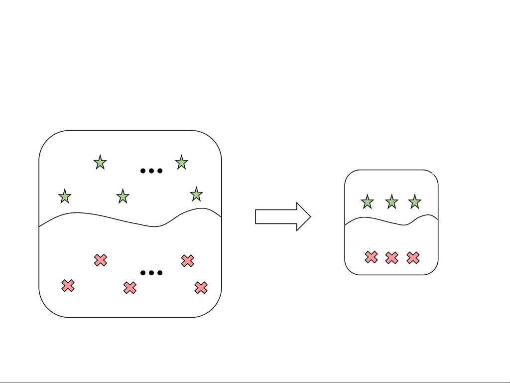

𝐾successes

𝑁 − 𝐾 failures

Population with 𝑁elements

Sample with 𝑛elements

𝑥successes

What is the probability to obtain 𝑥success in a sample with 𝑛elements?

[figure not shown]

Distribuci ´

on Hipergeom´

etrica

p(x) = P(X=x) = K

xN−K

n−x

N

n;x=0,1,2,··· ,min(n,K).

Esta funci´

on de probabilidad se conoce como Distribuci´

on Hipergeom´

etrica.

Se denotar´

aX∼Hiper(N,K,n). Donde N,K,nson los par ´

ametros de la

distribuci´

on.

E[X] = np

V[X] = N−n

N−1np (1−p).donde p =K/N

El t´

ermino N−n

N−1se conoce como factor de correcci ´

on por poblaci´

on ﬁnita

(muestra obtenida sin reemplazo). Observe que si nes muy peque˜

no compa-

rado con N, entonces el factor de correcci´

on tiende a uno, y la varianza de la

hipergeom´

etrica y la binomial son similares.

Estad´

ıstica I (Clase 5).

13

En R: dhyper(x, # éxitos Pob, # fracasos Pob, tamaño muestra)

[figure not shown]

Distribuci ´

on Hipergeom´

etrica

Los experimentos que tienen este tipo de distribuci´

on tienen las siguientes

caracter´

ısticas:

Se esperan dos tipos de resultados: ´

Exito o fracaso

Cada ensayo o repetici´

on no es independiente de los dem´

as.

Las probabilidades asociadas a cada uno de los resultados no son cons-

tantes

La distribuci´

on hipergeom´

etrica es apropiada para modelar experimentos

donde se hace muestras sin reemplazo o en poblaciones ﬁnitas.

Estad´

ıstica I (Clase 5).

14

[figure not shown]

Ejemplo Hipergeom´

etrica

Un lote con 25 arandelas contiene tres en las que la variabilidad en el espesor

alrededor de la circunferencia es inaceptable. Se toma una muestra al azar de

tres arandelas sin reemplazo.

a) ¿Cu´

al es la probabilidad de que ninguna de las arandelas inaceptables

se encuentren en la muestra?

b) ¿Cu´

al es la probabilidad de que al menos una de las arandelas inacepta-

bles se encuentren en la muestra?

c) ¿Cu´

al es la probabilidad de que exactamente una de las arandelas inacep-

tables se encuentre en la muestra?

Estad´

ıstica I (Clase 5).

15

X es el # de arand. inacep. Por esa razón X ~ hyper(N=25, K=3, n=3)

[figure not shown]

Ejemplo Hipergeom´

etrica

Soluci ´

on

Sea X: # de arandelas inaceptables en la muestra.

La f.m.p. de Xes de la forma:

p(x) = 3

x22

3−x

25

3;x=0,1,2,3.

a) P(X=0) = p(0) = (22

3)

(25

3)=1540

2300 =0.66957 .

En R: dhyper(x, K, N-K, n)

b) P(X≥1) = 1−P(X<1) = 1−p(0) = 1−0.66957 =0.33043 .

Estad´

ıstica I (Clase 5).

16

En R: dhyper(x=0, 3, 22, 3)

Forma 1: 1 - dhyper(x=0, 3, 22, 3)

Forma 2: sum(dhyper(x=1:3, 3, 22, 3))

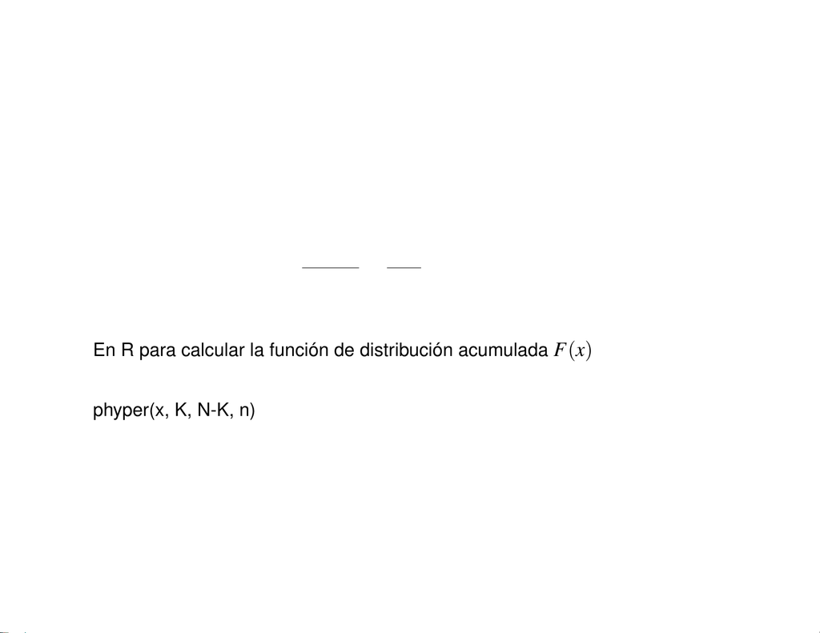

c) P(X=1) = p(1) = (3

1) (22

2)

(25

3)=693

2300 =0.30130 .

En R para calcular la funci´

on de distribuci´

on acumulada F(x)

phyper(x, K, N-K, n)

En R: dhyper(x=1, 3, 22, 3)

d) Calcular P(X ≤ 2) usando F(x) en R.

En R: phyper(q=2, 3, 22, 3)

[figure not shown]

Ejemplo Hipergeom´

etrica

Un ge´

ologo ha recolectado 10 especimenes de roca bas´

altica y 10 de granito.

Se instruye a un asistente de laboratorio para que seleccione al azar 6 de los

especimenes sin reemplazo para analizarlos.

a) ¿Cu´

al es la f.m.p. para el n´

umero de especimenes de basalto seleccio-

nados para analizarlos?

b) ¿Cu´

al es la probabilidad de que todos los especimenes de la muestra

sean de uno de los dos tipos de roca seleccionados para el an´

alisis?

c) ¿Cu´

al es la probabilidad de que la cantidad de especimenes de basalto

seleccionados para su an´

alisis est´

e a menos de una desviaci´

on est´

andar

de la media?

Estad´

ıstica I (Clase 5).

17

[figure not shown]

Ejemplo Hipergeom´

etrica

Soluci ´

on

Sea X: # de especimenes de basalto en la muestra para an´

alisis.

a)

p(x) = 10

x10

6−x

20

6;x=0,1,2,3,4,5,6.

b)

P(X=6∨X=0) = P(X=0) + P(X=6) = p(0) + p(6)

=10

6

20

6+10

6

20

6=210 +210

38760 =0.01084 .

Estad´

ıstica I (Clase 5).

18

[figure not shown]

Ejemplo Hipergeom´

etrica

c)

E[X] = 610

20=3Var [X] = 20 −6

20 −1610

201−10

20

Var [X] = 14

196

4=21

19 =1.10526 yσ=r21

19 =1.05 .

P(|X−µx|≤σ) = P −r21

19 ≤X−3≤r21

19!=P(1.95 ≤X≤4.05).

P(|X−µx|≤σ) = P(2≤X≤4) = p(2) + p(3) + p(4).

P(|X−µx|≤σ) = 9450

38760 +14400

38760 +9450

38760 =0.85913 .

phyper(4,10,10,6)-phyper(1,10,10,6)

Estad´

ıstica I (Clase 5).

19

[figure not shown]

Teorema de Aproximaci ´

on

Sea Xuna variable aleatoria tal que X∼Hiper(N,K,n).

N−n

N−1≈1, si n/N≤0.05 entonces:

K

xN−K

n−x

N

n≈n

xpx(1−p)n−x;donde p=K

N.

Este resultado se conoce como Aproximaci ´

on Binomial de la Hipergeom´

etrica.

Por ejemplo: si N=200, n=5, K=30 la relaci´

on n/N=0.025 <0.05, entonces,

calculemos la P(X=3), se tiene que:

P(X=3) = 30

3170

2

200

5=0.023

Usando la aproximaci ´

on se tiene que:

P(X=3)≈5

33

20317

202

=0.024

Estad´

ıstica I (Clase 5).

20

[figure not shown]

Ejercicio

Un gran distribuidor tiene 800 equipos de computo. Se sabe que

8de ellos est´

an defectuosos, una compa ˜

n´

ıa compra 20 de ellos

y le son despachados al azar, ¿c´

ual es la probabilidad de que en

la muestra se observen 2 o m ´

as defectuosos?

Estad´

ıstica I (Clase 5).

21

X es el # de defectuosos. Por esa razón X ~ hyper(N=800, K=8, n=20)